# Optimization Routines

# This is the Optimization Demonstration for GBM-BRT

## Approach

### Uncontrained Optimization

1. Use a combination of prediction and interpolation to predict all values oftime and accuracy under different hardware/software configurations.
2. Find the minimal combination of algorithm inputs that maximize accuracy. If there are ties, break them by using the point that requires the least data.
3. Find the costs associated with running the algorithm with those inputs on all different hardware configurations.
4. Find the combination of hardware that jointly minimizes cost and time.

### Data-contrained Optimization

1. Use a combination of prediction and interpolation to predict all values oftime and accuracy under different hardware/software configurations.
2. Subset the accuracy surface produced above to the amount of data available. The maximizing point will fall in the upper right corner of the subsetted space.
3. Find the costs associated with running the algorithms with the accuracy-maximizing point on all different hardwares.
4. Find the combination of hardware that jointly minimizes time and cost.

### Cost-constrained Optimization

1. Use a combination of prediction and interpolation to predict all values oftime and accuracy under different hardware/software configurations.
2. Subset the space produced above to the amount of time and money able to be spent on modelling.
3. Working backwards now, find the accuracies that can be produced in the limited time.
4. Using the subset of accuracy space, find the combination of algorithm inputs that maximizes accuracy.

```r
knitr::opts_chunk$set(cache=F, echo=F, warning=F, error = F, message=F)
knitr::opts_knit$set(root.dir = "/users/scottsfarley/documents")
setwd("/users/scottsfarley/documents")
library(parallel)
library(doParallel)
```

```r
library(akima)
library(ggplot2)
options(java.parameters = "-Xmx1500m")
library(bartMachine)
bartMachine::set_bart_machine_num_cores(3)
```

```
## bartMachine now using 3 cores.
```

```r
library(reshape2)
library(ggdendro)
threshold.time <- 20 ##seconds
threshold.cost <- Inf ##cents
threshold.numTex <- 45

numKeep = 100
dissimilarityCut <- 0.5
```

First, get the training data and fit the model. Perform some skill checks on it.

[output not shown]

[output not shown]

Choose a finite number of possible solutions to the model. Ideally, we would want every single combination of predictor variables [0, Inf]. This is obviously intractable. Moreover, I only have data for a subset of that space anyways. So randomly sample the subspace in which I have data to make the problem possible to solve.

Using that subset of data and the models we fit previously, predict each candidate configuration of algorithm inputs and hardware variables for execution time and SDM accuracy.

Plot the posterior means of the accuracy models against the algorithm inputs that should control accuracy. In this case, these are number of training examples and number of covariates.

The accuracy clearly varies from low (few training examples and few covariates) to very high (many covariates, many training examples). Perhaps more data would be helpful here, but what are you going to do. Our task is to find the combinations of inputs that results in the highest accuracy model. If there’s a tie, find the combination that needs the least data.

Now, we know the combination of algorithm inputs that result in the highest accuracy. The figure below shows the combination identified on the training examples and covariates axes. This combination of training examples and number of covariates can be run on any combination of hardware. Some might be suboptimal. Thus, at this point, we’ve solved half of our challenge: algorithm inputs have been optimized, now it’s time optimize hardware.

```
## [1] "Accuracy is maximized at 10000 training examples and 5 predictors."
```

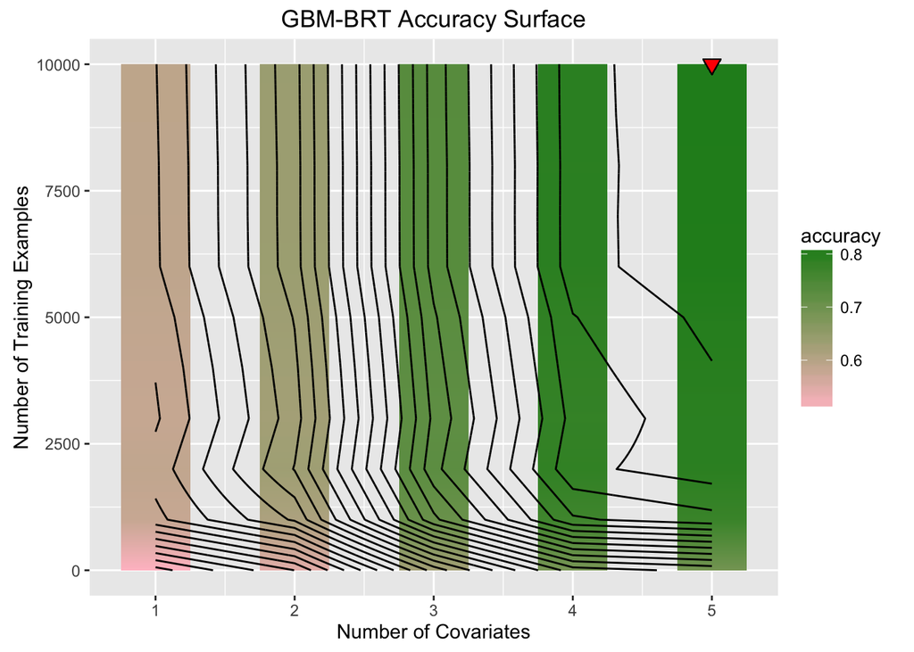

```
## [1] "Accuracy Range on Hardware:  0.0312428925738556"
```

```
## [1] "Accuracy Range from Expectation:  0"
```

```
## [1] "------"
```

```
## [1] "Fixing accuracy at:  0.809379472312607"
```

Our job is complete. We’ve now optimized both the harware and software dimensions of the problem.

Everything up to this point was done using the mean of the posterior distribution, a choice which simplifies the process but causes some information loss and may cause over-confidence in the predictions. We can modify our steps to include information from the entire posterior, which may solve this issue.

Instead of projecting just the mean time and mean cost for use the the distance minimization, use the entire set of posterior samples. Calculate the distance metric for each sample in the posterior independently. You’re then left with a density distribution of distances, from which we can infer the minimum value.

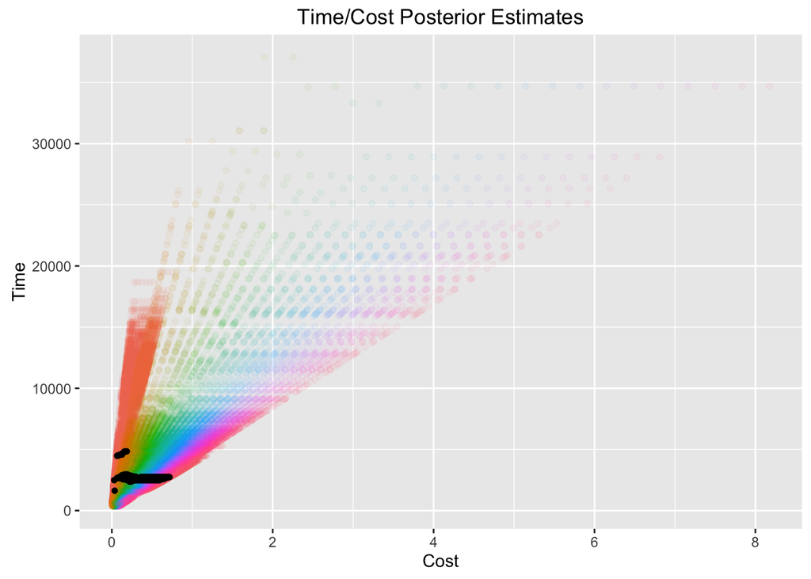

The posteriors are in a line, since there’s a fixed linear relationship between time and cost.

Now, find the distance metrics for all of those points.

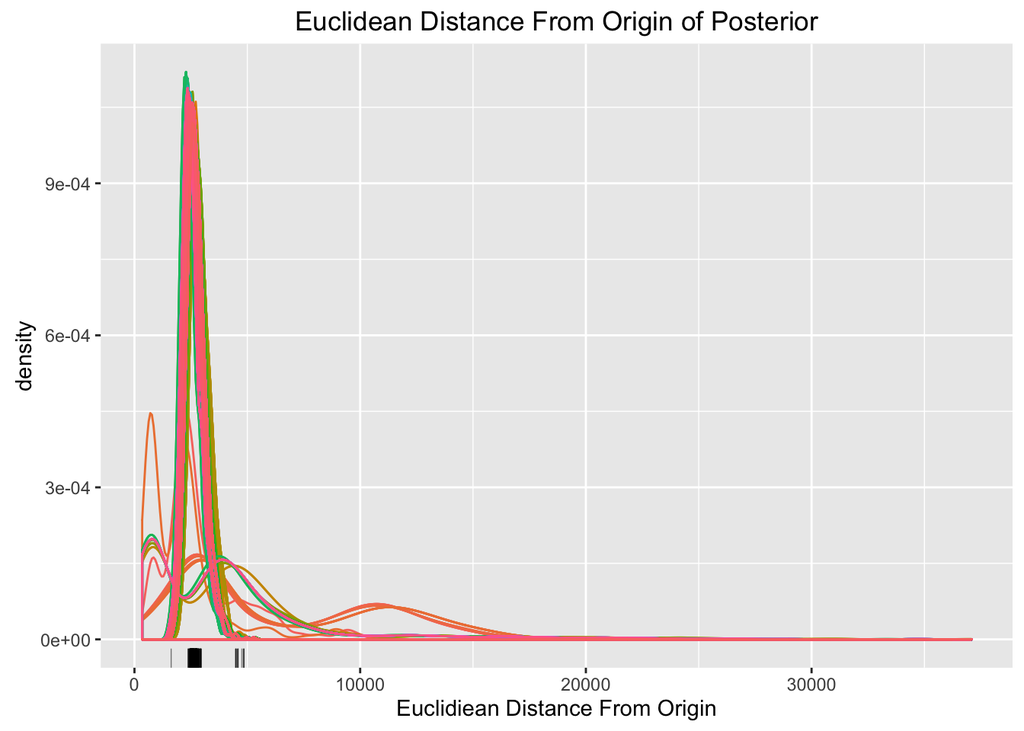

There’s a lot of overlab in this figure, and many points are far away from the optimal. We don’t care about those. Take the few closest to the minimum and look at their distributions.

Now, the optimal configuration may be one of the following:

[figure not shown]

| config | cores | GBMemory | seconds | cost | distance.mean | distance.sd | cluster | meanDistance | sdDistance |
| --- | --- | --- | --- | --- | --- | --- | --- | --- | --- |
| 13 | 2 | 2 | 1625.464 | 0.0357602 | 2151.073 | 1803.6066 | 1 | 2151.073 | 1803.6066 |
| 98 | 9 | 4 | 2376.374 | 0.2198146 | 2409.044 | 408.9328 | 2 | 2476.781 | 404.5305 |
| 110 | 10 | 4 | 2376.374 | 0.2428654 | 2409.044 | 408.9328 | 2 | 2476.781 | 404.5305 |
| 99 | 9 | 5 | 2436.922 | 0.2285833 | 2465.930 | 389.3782 | 2 | 2476.781 | 404.5305 |
| 100 | 9 | 6 | 2436.922 | 0.2317513 | 2465.930 | 389.3782 | 2 | 2476.781 | 404.5305 |
| 111 | 10 | 5 | 2436.922 | 0.2522214 | 2465.930 | 389.3782 | 2 | 2476.781 | 404.5305 |
| 112 | 10 | 6 | 2436.922 | 0.2553894 | 2465.930 | 389.3782 | 2 | 2476.781 | 404.5305 |
| 101 | 9 | 8 | 2459.509 | 0.2402940 | 2488.855 | 392.0919 | 2 | 2476.781 | 404.5305 |
| 113 | 10 | 8 | 2459.509 | 0.2641513 | 2488.855 | 392.0919 | 2 | 2476.781 | 404.5305 |
| 122 | 11 | 4 | 2473.826 | 0.2768211 | 2507.535 | 424.1266 | 2 | 2476.781 | 404.5305 |
| 134 | 12 | 4 | 2473.826 | 0.3008172 | 2507.535 | 424.1266 | 3 | 2561.038 | 411.1818 |
| 146 | 13 | 4 | 2479.022 | 0.3254956 | 2513.077 | 426.8838 | 3 | 2561.038 | 411.1818 |
| 158 | 14 | 4 | 2479.022 | 0.3495421 | 2513.077 | 426.8838 | 3 | 2561.038 | 411.1818 |
| 170 | 15 | 4 | 2479.022 | 0.3735886 | 2513.077 | 426.8838 | 3 | 2561.038 | 411.1818 |
| 182 | 16 | 4 | 2479.022 | 0.3976351 | 2513.077 | 426.8838 | 4 | 2564.008 | 411.8620 |
| 194 | 17 | 4 | 2479.022 | 0.4216816 | 2513.077 | 426.8838 | 4 | 2564.008 | 411.8620 |
| 205 | 18 | 2 | 2505.128 | 0.4439086 | 2513.077 | 426.8838 | 4 | 2564.008 | 411.8620 |
| 217 | 19 | 2 | 2505.128 | 0.4682083 | 2513.077 | 426.8838 | 4 | 2564.008 | 411.8620 |
| 229 | 20 | 2 | 2505.128 | 0.4925081 | 2513.077 | 426.8838 | 5 | 2563.908 | 411.9280 |
| 241 | 21 | 2 | 2505.128 | 0.5168078 | 2513.077 | 426.8838 | 5 | 2563.908 | 411.9280 |
| 253 | 22 | 2 | 2505.128 | 0.5411076 | 2513.077 | 426.8838 | 5 | 2563.908 | 411.9280 |
| 265 | 23 | 2 | 2505.128 | 0.5654073 | 2513.077 | 426.8838 | 5 | 2563.908 | 411.9280 |
| 277 | 24 | 2 | 2505.128 | 0.5897070 | 2513.077 | 426.8838 | 5 | 2563.908 | 411.9280 |
| 74 | 7 | 4 | 2504.139 | 0.1830526 | 2538.769 | 433.0733 | 2 | 2476.781 | 404.5305 |
| 86 | 8 | 4 | 2504.139 | 0.2073427 | 2538.769 | 433.0733 | 2 | 2476.781 | 404.5305 |
| 123 | 11 | 5 | 2536.857 | 0.2871722 | 2566.816 | 404.0066 | 3 | 2561.038 | 411.1818 |
| 124 | 11 | 6 | 2536.857 | 0.2904701 | 2566.816 | 404.0066 | 3 | 2561.038 | 411.1818 |
| 135 | 12 | 5 | 2536.857 | 0.3117797 | 2566.816 | 404.0066 | 3 | 2561.038 | 411.1818 |
| 136 | 12 | 6 | 2536.857 | 0.3150776 | 2566.816 | 404.0066 | 3 | 2561.038 | 411.1818 |
| 147 | 13 | 5 | 2542.185 | 0.3370938 | 2572.398 | 406.3115 | 3 | 2561.038 | 411.1818 |

[output cut: 70 more lines]

### Data Constraint

In this case, we’ve got a constraint on the amount of data available to us.

```
## [1] "Current data threshold is  45"
```

```
## [1] "Accuracy is maximized at 44 training examples and 5 predictors."
```

```
## [1] "Expected Max Accuracy is  0.696689251816358"
```

```
## [1] "Now there are only:  287 candidates, instead of  287 candidates that can complete this scenario under budget."
```

```
## [1] "Recommended # cores:  9"
```

```
## [1] "Recommended Memory:  4"
```

```
## [1] "Expected Cost:  0.000820974815727121"
```

```
## [1] "Expected Seconds:  8.87540341326617"
```

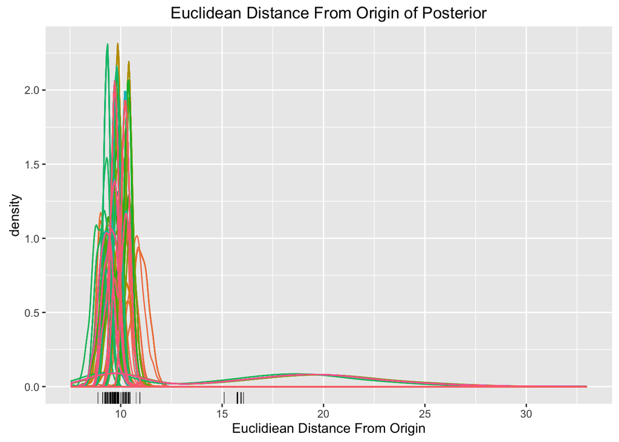

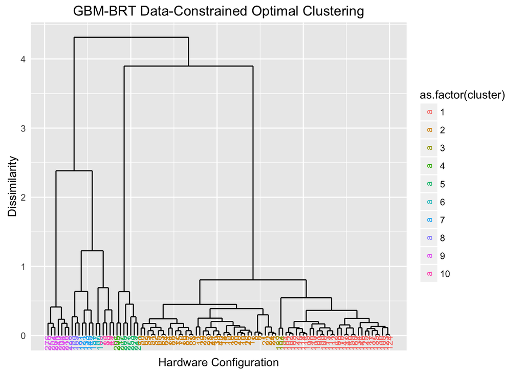

[output not shown]

[output cut: 70 more lines]

### Cost Constraint

```
## [1] "Best Configuration:  5"
## [2] "Best Configuration:  29"
## [3] "Best Configuration:  19.9632655817107"
## [4] "Best Configuration:  0.00102012287122542"
## [5] "Best Configuration:  0.689092821457327"
## [6] "Best Configuration:  5"
## [7] "Best Configuration:  2"
## [8] "Best Configuration:  5.11e-05"
## [9] "Best Configuration:  49"
```

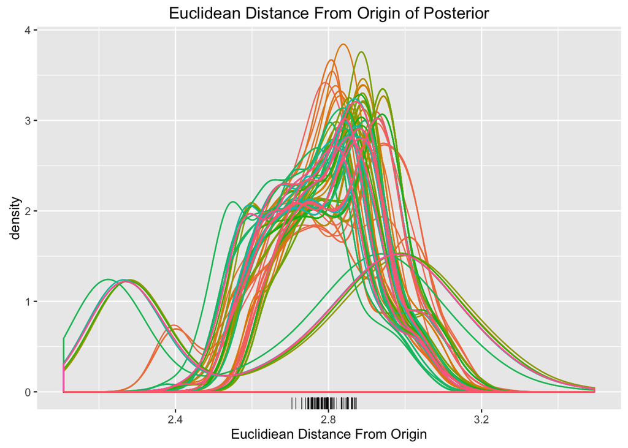

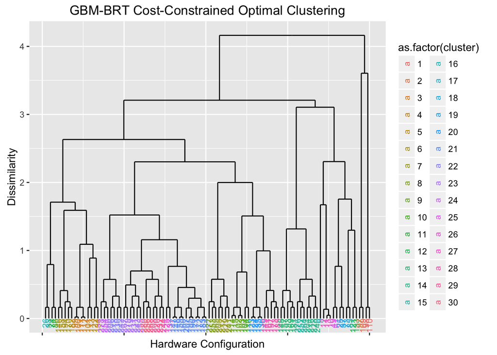

| config | cores | GBMemory | seconds | cost | distance.mean | distance.sd | cluster | meanDistance | sdDistance |
| --- | --- | --- | --- | --- | --- | --- | --- | --- | --- |
| 98 | 9 | 4 | 19.98390 | 0.0018485 | 2.704393 | 0.1426232 | 1 | 2.704393 | 0.1426232 |
| 110 | 10 | 4 | 19.98390 | 0.0020424 | 2.704393 | 0.1426232 | 1 | 2.704393 | 0.1426232 |
| 97 | 9 | 2 | 19.91265 | 0.0017901 | 2.714622 | 0.3539508 | 2 | 2.714622 | 0.3539508 |
| 109 | 10 | 2 | 19.91265 | 0.0019833 | 2.714622 | 0.3539508 | 2 | 2.714622 | 0.3539508 |
| 99 | 9 | 5 | 19.96245 | 0.0018725 | 2.729968 | 0.1334681 | 3 | 2.729968 | 0.1334681 |
| 100 | 9 | 6 | 19.96245 | 0.0018984 | 2.729968 | 0.1334681 | 3 | 2.729968 | 0.1334681 |
| 111 | 10 | 5 | 19.96245 | 0.0020661 | 2.729968 | 0.1334681 | 3 | 2.729968 | 0.1334681 |
| 112 | 10 | 6 | 19.96245 | 0.0020921 | 2.729968 | 0.1334681 | 3 | 2.729968 | 0.1334681 |
| 101 | 9 | 8 | 19.93400 | 0.0019476 | 2.740099 | 0.1372166 | 4 | 2.740099 | 0.1372166 |
| 113 | 10 | 8 | 19.93400 | 0.0021409 | 2.740099 | 0.1372166 | 4 | 2.740099 | 0.1372166 |
| 122 | 11 | 4 | 19.95513 | 0.0022330 | 2.745404 | 0.1424542 | 5 | 2.745404 | 0.1424542 |
| 134 | 12 | 4 | 19.95513 | 0.0024265 | 2.745404 | 0.1424542 | 5 | 2.745404 | 0.1424542 |
| 146 | 13 | 4 | 19.92329 | 0.0026159 | 2.747972 | 0.1423519 | 6 | 2.747972 | 0.1423519 |
| 158 | 14 | 4 | 19.92329 | 0.0028092 | 2.747972 | 0.1423519 | 6 | 2.747972 | 0.1423519 |
| 170 | 15 | 4 | 19.92329 | 0.0030024 | 2.747972 | 0.1423519 | 6 | 2.747972 | 0.1423519 |
| 182 | 16 | 4 | 19.92329 | 0.0031957 | 2.747972 | 0.1423519 | 6 | 2.747972 | 0.1423519 |
| 194 | 17 | 4 | 19.92329 | 0.0033890 | 2.747972 | 0.1423519 | 6 | 2.747972 | 0.1423519 |
| 205 | 18 | 2 | 19.99967 | 0.0035439 | 2.747972 | 0.1423519 | 7 | 2.747972 | 0.1423519 |
| 217 | 19 | 2 | 19.99967 | 0.0037379 | 2.747972 | 0.1423519 | 7 | 2.747972 | 0.1423519 |
| 229 | 20 | 2 | 19.99967 | 0.0039319 | 2.747972 | 0.1423519 | 7 | 2.747972 | 0.1423519 |
| 241 | 21 | 2 | 19.99967 | 0.0041259 | 2.747972 | 0.1423519 | 7 | 2.747972 | 0.1423519 |
| 253 | 22 | 2 | 19.99967 | 0.0043199 | 2.747972 | 0.1423519 | 8 | 2.747972 | 0.1423519 |
| 265 | 23 | 2 | 19.99967 | 0.0045139 | 2.747972 | 0.1423519 | 8 | 2.747972 | 0.1423519 |
| 277 | 24 | 2 | 19.99967 | 0.0047079 | 2.747972 | 0.1423519 | 8 | 2.747972 | 0.1423519 |
| 102 | 9 | 10 | 19.98066 | 0.0020041 | 2.754240 | 0.1378852 | 9 | 2.754240 | 0.1378852 |
| 103 | 9 | 12 | 19.98066 | 0.0020560 | 2.754240 | 0.1378852 | 9 | 2.754240 | 0.1378852 |
| 114 | 10 | 10 | 19.98066 | 0.0021979 | 2.754240 | 0.1378852 | 9 | 2.754240 | 0.1378852 |
| 115 | 10 | 12 | 19.98066 | 0.0022498 | 2.754240 | 0.1378852 | 9 | 2.754240 | 0.1378852 |
| 104 | 9 | 14 | 19.99849 | 0.0021098 | 2.755123 | 0.1383461 | 10 | 2.755123 | 0.1383461 |
| 116 | 10 | 14 | 19.99849 | 0.0023038 | 2.755123 | 0.1383461 | 10 | 2.755123 | 0.1383461 |

[output cut: 70 more lines]